# **Problem Statement**

#### **Business Context**

Understanding customer personality and behavior is pivotal for businesses to enhance customer satisfaction and increase revenue. Segmentation based on a customer's personality, demographics, and purchasing behavior allows companies to create tailored marketing campaigns, improve customer retention, and optimize product offerings.

A leading retail company with a rapidly growing customer base seeks to gain deeper insights into their customers' profiles. The company recognizes that understanding customer personalities, lifestyles, and purchasing habits can unlock significant opportunities for personalizing marketing strategies and creating loyalty programs. These insights can help address critical business challenges, such as improving the effectiveness of marketing campaigns, identifying high-value customer groups, and fostering long-term relationships with customers.

With the competition intensifying in the retail space, moving away from generic strategies to more targeted and personalized approaches is essential for sustaining a competitive edge.

#### **Objective**

In an effort to optimize marketing efficiency and enhance customer experience, the company has embarked on a mission to identify distinct customer segments. By understanding the characteristics, preferences, and behaviors of each group, the company aims to:

1. Develop personalized marketing campaigns to increase conversion rates.
2. Create effective retention strategies for high-value customers.
3. Optimize resource allocation, such as inventory management, pricing strategies, and store layouts.

As a data scientist tasked with this project, your responsibility is to analyze the given customer data, apply machine learning techniques to segment the customer base, and provide actionable insights into the characteristics of each segment.

#### **Data Dictionary**

The dataset includes historical data on customer demographics, personality traits, and purchasing behaviors. Key attributes are:

1. **Customer Information**
   - **ID:** Unique identifier for each customer.
   - **Year_Birth:** Customer's year of birth.
   - **Education:** Education level of the customer.
   - **Marital_Status:** Marital status of the customer.
   - **Income:** Yearly household income (in dollars).
   - **Kidhome:** Number of children in the household.
   - **Teenhome:** Number of teenagers in the household.
   - **Dt_Customer:** Date when the customer enrolled with the company.
   - **Recency:** Number of days since the customer’s last purchase.
   - **Complain:** Whether the customer complained in the last 2 years (1 for yes, 0 for no).
2. **Spending Information (Last 2 Years)**
   - **MntWines:** Amount spent on wine.
   - **MntFruits:** Amount spent on fruits.
   - **MntMeatProducts:** Amount spent on meat.
   - **MntFishProducts:** Amount spent on fish.
   - **MntSweetProducts:** Amount spent on sweets.
   - **MntGoldProds:** Amount spent on gold products.
3. **Purchase and Campaign Interaction**
   - **NumDealsPurchases:** Number of purchases made using a discount.
   - **AcceptedCmp1:** Response to the 1st campaign (1 for yes, 0 for no).
   - **AcceptedCmp2:** Response to the 2nd campaign (1 for yes, 0 for no).
   - **AcceptedCmp3:** Response to the 3rd campaign (1 for yes, 0 for no).
   - **AcceptedCmp4:** Response to the 4th campaign (1 for yes, 0 for no).
   - **AcceptedCmp5:** Response to the 5th campaign (1 for yes, 0 for no).
   - **Response:** Response to the last campaign (1 for yes, 0 for no).
4. **Shopping Behavior**
   - **NumWebPurchases:** Number of purchases made through the company’s website.
   - **NumCatalogPurchases:** Number of purchases made using catalogs.
   - **NumStorePurchases:** Number of purchases made directly in stores.
   - **NumWebVisitsMonth:** Number of visits to the company’s website in the last month.

# **Let's start coding!**

## **Importing necessary libraries**

```python
# Libraries to help with reading and manipulating data
import pandas as pd
import numpy as np

# libaries to help with data visualization
import matplotlib.pyplot as plt
import seaborn as sns

# Removes the limit for the number of displayed columns
pd.set_option("display.max_columns", None)
# Sets the limit for the number of displayed rows
pd.set_option("display.max_rows", 200)

# to scale the data using z-score
from sklearn.preprocessing import StandardScaler

# to compute distances
from scipy.spatial.distance import cdist, pdist

# to perform k-means clustering and compute silhouette scores
from sklearn.cluster import KMeans
from sklearn.metrics import silhouette_score

# to suppress warnings
import warnings

warnings.filterwarnings("ignore")
```

## **Loading the data**

```python
# uncomment and run the following line if using Google Colab
# from google.colab import drive
# drive.mount('/content/drive')
```

```python
# loading data into a pandas dataframe
df = pd.read_csv("Customer_Personality_Segmentation.csv", sep="\t")
df.head()
```

## **Data Overview**

```python
# Problem Defintion: The purpose of the progross is to use the unsupervised learning method which breaks up the customer data into groups based on key characteristics. Then based on the findings, the goal would be to make marketing strategies to improve the business
```

```python
# Data Description: The data set has 2240 customers with 29 attributes shown in the number of columns.
```

#### **Question 1**: What are the data types of all the columns?

```python
# Presents datatype of the columns
df.info()
```

```
<class 'pandas.core.frame.DataFrame'>
RangeIndex: 2240 entries, 0 to 2239
Data columns (total 30 columns):
 #   Column               Non-Null Count  Dtype
---  ------               --------------  -----
 0   ID                   2240 non-null   int64
 1   Year_Birth           2240 non-null   int64
 2   Education            2240 non-null   object
 3   Marital_Status       2240 non-null   object
 4   Income               2216 non-null   float64
 5   Kidhome              2240 non-null   int64
 6   Teenhome             2240 non-null   int64
 7   Dt_Customer          2240 non-null   object
 8   Recency              2240 non-null   int64
 9   MntWines             2240 non-null   int64
```

[output cut: 23 more lines]

#### **Question 2:** Check the statistical summary of the data. What is the average household income?

```python
# Shows the average household income from the data set
df.describe().T
df['Income'].mean()
```

```
52247.25135379061
```

##### Observations: The average household income is about $52,247.

#### **Question 3:** Are there any missing values in the data? If yes, treat them using an appropriate method

```python
# Shows the missing values from the dataset
df.isna().sum()
```

```
ID                      0
Year_Birth              0
Education               0
Marital_Status          0
Income                 24
Kidhome                 0
Teenhome                0
Dt_Customer             0
Recency                 0
MntWines                0
MntFruits               0
MntMeatProducts         0
MntFishProducts         0
MntSweetProducts        0
MntGoldProds            0
NumDealsPurchases       0
NumWebPurchases         0
NumCatalogPurchases     0
NumStorePurchases       0
NumWebVisitsMonth       0
AcceptedCmp3            0
AcceptedCmp4            0
AcceptedCmp5            0
AcceptedCmp1            0
AcceptedCmp2            0
Complain                0
Z_CostContact           0
Z_Revenue               0
Response                0
dtype: int64
```

##### Observations: Based on the output the only column with missing values is Income.

#### **Question 4**: Are there any duplicates in the data?

```python
# Shows how many duplicates are found in the dataset
df.duplicated().sum()
```

```
0
```

##### Observations: There are no duplicates in the data.

## **Exploratory Data Analysis**

### Univariate Analysis

#### **Question 5:** Explore all the variables and provide observations on their distributions. (histograms and boxplots)

```
array([[<Axes: title={'center': 'ID'}>,
        <Axes: title={'center': 'Year_Birth'}>,
        <Axes: title={'center': 'Income'}>,
        <Axes: title={'center': 'Kidhome'}>,
        <Axes: title={'center': 'Teenhome'}>],
       [<Axes: title={'center': 'Recency'}>,
        <Axes: title={'center': 'MntWines'}>,
        <Axes: title={'center': 'MntFruits'}>,
        <Axes: title={'center': 'MntMeatProducts'}>,
        <Axes: title={'center': 'MntFishProducts'}>],
       [<Axes: title={'center': 'MntSweetProducts'}>,
        <Axes: title={'center': 'MntGoldProds'}>,
        <Axes: title={'center': 'NumDealsPurchases'}>,
        <Axes: title={'center': 'NumWebPurchases'}>,
        <Axes: title={'center': 'NumCatalogPurchases'}>],
       [<Axes: title={'center': 'NumStorePurchases'}>,
        <Axes: title={'center': 'NumWebVisitsMonth'}>,
        <Axes: title={'center': 'AcceptedCmp3'}>,
        <Axes: title={'center': 'AcceptedCmp4'}>,
        <Axes: title={'center': 'AcceptedCmp5'}>],
       [<Axes: title={'center': 'AcceptedCmp1'}>,
        <Axes: title={'center': 'AcceptedCmp2'}>,
        <Axes: title={'center': 'Complain'}>,
        <Axes: title={'center': 'Z_CostContact'}>,
        <Axes: title={'center': 'Z_Revenue'}>],
       [<Axes: title={'center': 'Response'}>,
        <Axes: title={'center': 'Cluster'}>, <Axes: >, <Axes: >,
        <Axes: >]], dtype=object)
```

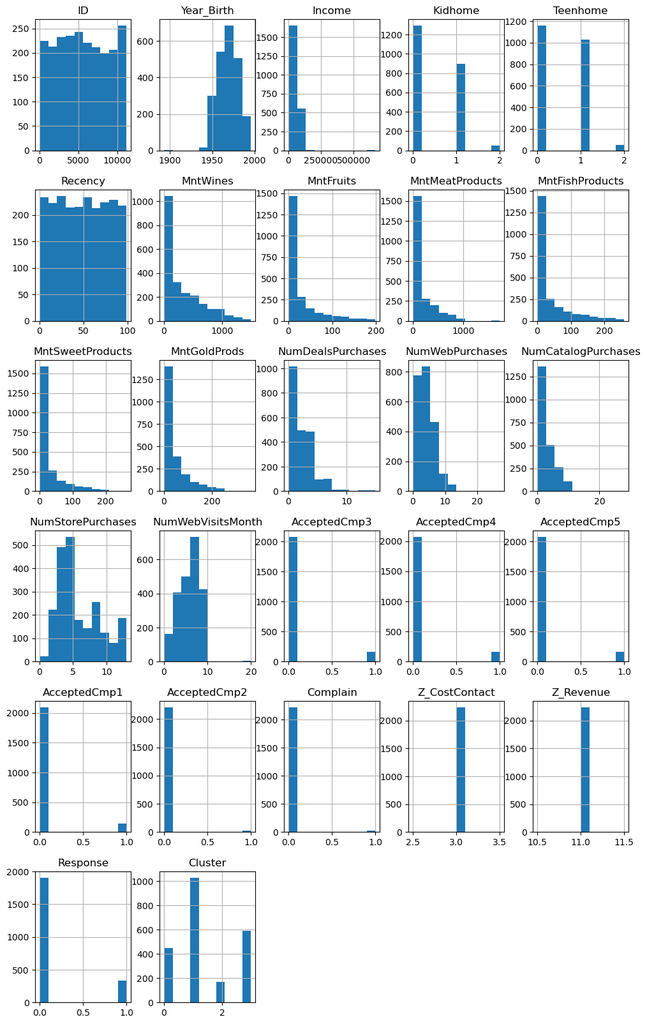

```python
# Presents the hisogram for each column
df.hist(figsize=(12,20))
```

##### Observations: Based on the historgrams, a lot of the variables that are numeric are right skewed. Moreover, there seems to be only a few high spenders showing the major discrepenacy in the incomes of the customers.

### Bivariate Analysis

#### **Question 6:** Perform multivariate analysis to explore the relationsips between the variables.

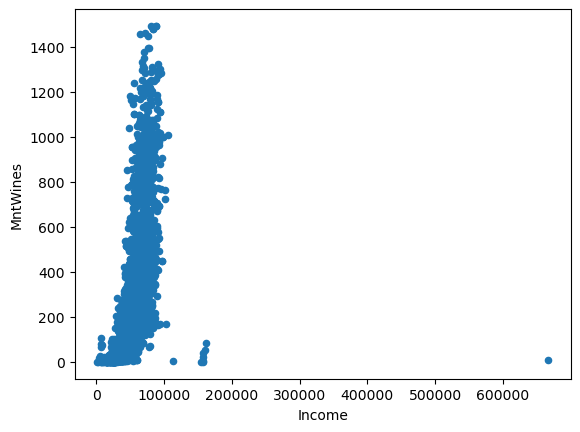

```python
# Creates a scatter plot to show the relationship between the income of customers and wine bought.
df.plot.scatter(x='Income', y='MntWines')
```

##### Observations: Based on the plot there seems to be a positive correlation between the income and amount of wine spent. Thus, the higher the income of the customes the more likely they are to spend on wine.

## **K-means Clustering**

#### **Question 7** : Select the appropriate number of clusters using the elbow Plot. What do you think is the appropriate number of clusters?

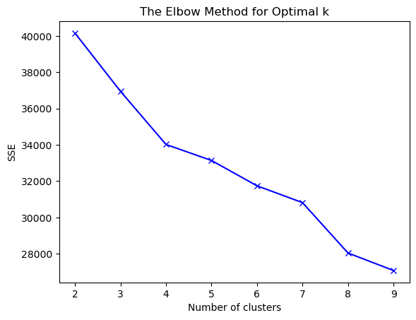

```python
# A empty dictionary was set to store the SSE for the values through K which is itereated in the for loop.
sse = {}
for k in range(2, 10):
    kmeans = KMeans(n_clusters=k, random_state=1).fit(X_scaled)
    sse[k] = kmeans.inertia_

# Elbow plot
plt.plot(list(sse.keys()), list(sse.values()), 'bx-')
plt.xlabel("Number of clusters")
plt.ylabel("SSE")
plt.title("The Elbow Method for Optimal k")
plt.show()
```

##### Observation: The apprpriate number of clusters seems to be around 4 to 5.

#### **Question 8** : finalize appropriate number of clusters by checking the silhoutte score as well. Is the answer different from the elbow plot?

[figure not shown]

```python
# A empty dictionary was set to store the SC for the values through K which is itereated in the for loop.
# Then the Silhouette score is store in for K.
sc = {}

for k in range(2, 10):
    kmeans = KMeans(n_clusters=k, random_state=1).fit(X_scaled)
    labels = kmeans.predict(X_scaled)
    sc[k] = silhouette_score(X_scaled, labels)

# Elbow Plot
plt.plot(list(sc.keys()), list(sc.values()), 'bx-')
plt.xlabel("The Number of clusters")
plt.ylabel("The Silhouette Score")
plt.title("The Silhouette Method for Optimal k")
plt.show()
```

#### **Question 9**: Do a final fit with the appropriate number of clusters. How much total time does it take for the model to fit the data?

```python
# Intial timer
t0 = time.time()

# Final fit of the model
kmeans = KMeans(n_clusters=4, random_state=1).fit(X_scaled)

# Ending Timer
t1 = time.time()

# Cluster labels
df['Cluster'] = kmeans.labels_

# The total time taken
print((t1 - t0))
```

```
0.05649685859680176
```

##### Observations: The ouput shows that the total time taken for the model to fit the data of the 4 clusters is about 0.056 seconds.

## **Cluster Profiling and Comparison**

#### **Question 10**: Perform cluster profiling using boxplots for the K-Means algorithm. Analyze key characteristics of each cluster and provide detailed observations.

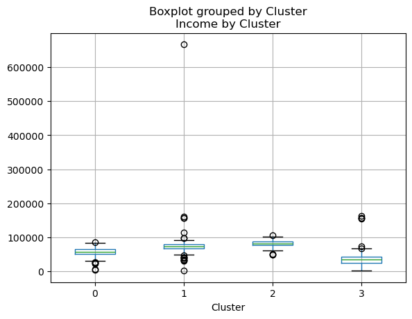

```python
# Boxplot of the clusters
plt.figure(figsize=(12,20))
df.boxplot(column='Income', by='Cluster')
plt.title("Income by Cluster")
plt.show()
```

##### Observations: Cluster 2 has the highest median income while cluster 3 has the lowest median income by a lot compared to the other clusters. All the clusters have outliers, but cluster 1 has the most extreme amount of outliers on the higher income side. Overall, we see a vast distrubution in the income of customers across the clusters.

#### **Question 11**: Perform cluster profiling on the data using a barplot for the K-Means algorithm. Provide insights and key observations for each cluster based on the visual analysis.

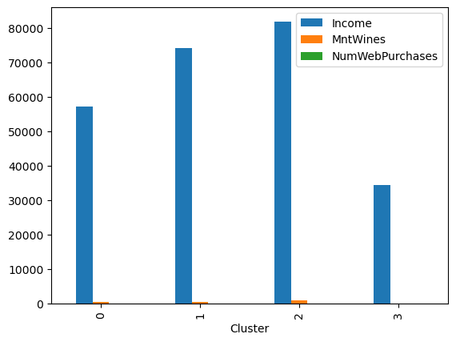

```python
# Barplot of the clusters for Income, MntWines, and NumWebPurchases.
df.groupby('Cluster')[['Income','MntWines','NumWebPurchases']].mean().plot.bar()
```

##### Observations: Cluster 2 has the highest wine spending and income while cluster 3 has the lowest wine spending and income by far. Therefore, further supporting the vast discrepencacy of customers in the market.

## **Business Recommedations**

#### **Question 12**: Based on the cluster insights, what business recommendations can be provided?

```python
### Based on the results of this project, it is vital to focus mostly on the customers from cluster 3 and cluster 0. Since cluster 3 seem to be customers with lower income, there should be more of a incentive for discounts and deals that promote consumers to purchase more goods: The same could be applied to cluster 0. For cluster 1 and 2 which have customers on the higher income end, they could be presented with special perks, premium products, or loyalty programs to better build the custome bonding. Therefore, this will lead to the continuous growth of the business.
```